# Data_Enhacement_Tool

## Attribute QAQC Tool - Technical Report

`Application: Was applied in ws3-RFP 1`

**Report By: Kevin Muhia Gathogo**

**Prepared on: 10-10-2023**

- 1. Introduction
  - 1.1 Overview of the tool
- 2. Database (SDE/GDB)
  - 2.1 Feature Dataset - Feature Class - Attribute Table
  - 2.2 Fields to Images
- 3. Create Folders
  - 3.1 Create Folders From Image Caption
  - 3.2 Removing Extension .png or .jpg from the folder name
- 4. Create Word Document
  - 4.1 Folder name to word documents by name
  - 4.2 Image Plot Explanation
- 5. Conclusion

## 1. Introduction

QA/QC of GIS data at its basic level involves geometry and attributes.

- **Geometry:-** Usually is about the location of features in terms of x, y and/or z. Apart from geoprocessing tools, we majorly relie on visual means, thats is, pan and check against a basemap (CGIS).
- **Attribute:-** Alot of query have to be made to check on standards, domains etc.

This tool, trys to alleviate the need of numerous query to check on the validity of attributes of feature. It's intent is to give:

- A wholistic VIEW of feature classes attributes.
- Unique Content in each Attribute field, together with its count.
- Image plots that makes its ease to capture an error, communicate an error and makes it easy for non-technical gis staff to understand.
- Give a visual means of quality check, similar to geometry checks.

### 1.1 Overview of the tool

We first access the geospatial database, whether its an enterprise SDE or a local file/personal geodatabase.

- Then we loop through each dataset, access each feature class in the datasets defined.
- In each feature class, we grab the fields one at a time, check how many unique entries are there, count the sum of each unique entry and plot them as images.
- This images, describe unique entries of the field in the x-axis, on the y axis is the count(number of times it appears in that field).

**Summary: Export images of all attribute fields of all feature classes to a defined location on your PC**

PWA GIS Features have common attribute fields in almost all the feature classes. Thus;

- Group them into a folder. that is, all common attribute fields of all features are grouped together.
- Take each folder by its name, common attribute name e.g Feature classes Road levels, Road lines, Carriageway have a common field Project Code.
- A folder with the name project code will have 3 image plots of project code for Road levels, Road lines and Carriageway.
- Plot the images in a word document. The document name and heading being the attribute field, the plot x -axis (Unique features) and Y-axis (Count of the unique features, null included)

**Summary: From the image folder, create a word document from the images. i.e, One attribute field of all the feature classes in one word document**

We import the necessary modules and libraries for these task.

```python
import pandas as pd
import numpy as np
import matplotlib.pyplot as plt
import arcpy


import os
import shutil
%matplotlib inline

from arcgis import GIS

import docx
from docx.enum.text import WD_ALIGN_PARAGRAPH
from docx.shared import Inches
from docx.shared import Pt
```

## 2. Database (SDE/GDB)

Basic outputs to check whether we can read the data

```python
# Specify the path to the dataset you want to describe
workspace = r"E:/Drive/WORKSPACE/2023/038_Zone94_95_96_97_98/Zone94-98/Zone94-98.gdb/ROADS"
arcpy.env.workspace = workspace

# Use arcpy.Describe() to get information about the dataset
desc = arcpy.Describe(workspace)

# Access properties of the dataset
print(f"Dataset Name: {desc.name}")
print(f"Data Type: {desc.dataType}")
print(f"Coordinate System: {desc.spatialReference.name}")
#print(f"Number of features: {desc.featureCount}")
print(f"Extent: {desc.extent.XMin}, {desc.extent.YMin}, {desc.extent.XMax}, {desc.extent.YMax}")
```

```
Dataset Name: ROADS
Data Type: FeatureDataset
Coordinate System: QND_1995_Qatar_National_Grid
Extent: 160253.10929999966, 308731.02040000074, 236828.29140000045, 386415.9329000009
```

### 2.1 Feature Dataset - Feature Class - Attribute Table

- The below images are the description of the database, can be either enterprise or local .gdb.
- Iteration/ looping is in datasets, feature classes and attribute fields.

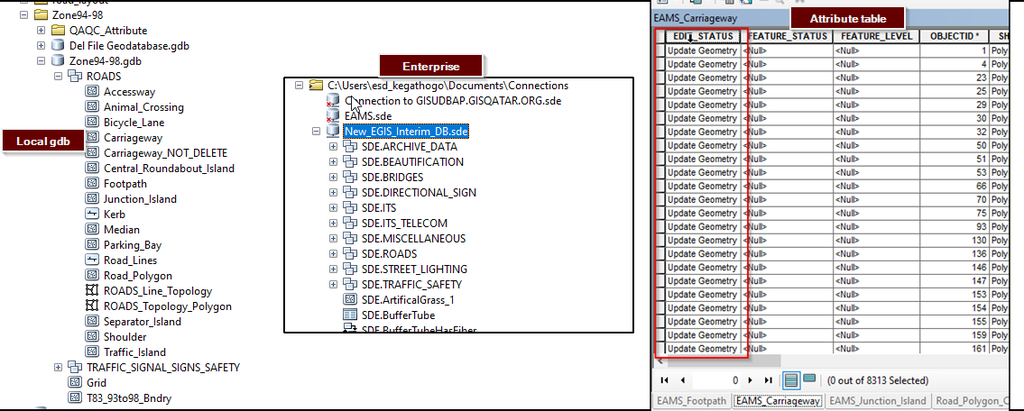

### 2.2 Fields to Images

Each field is grabbed and plotted to an image. The following describe all the images plotted

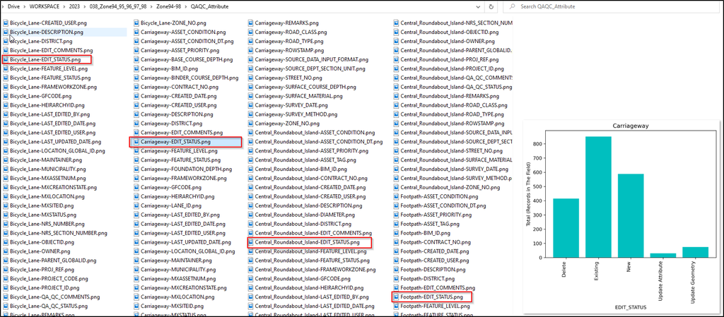

Below is the code that does the above with explained comments:

- Define our workspace and GIS environment:-Standard Procedure
- We connect to the Enterprise database or local gdb.
- Iterate dataset at a time. In each dataset, we loop the various feature classes.
- Create a temporary or copy of a feature class using `arcpy.MakeFeatureLayer_management`.
- Create a dataframe in order to filter by columns.
- Store columns/fields of the dataframe or you can call it attribute table of a feaure class in a list
- Iterate each column of the feature class, omitting the `SHAPE` field and sum the unique elements in the column.
- Plot the count of unique elements using a matplotlib colours.
- Save the images in a define folder location. All Images of defined columns in features classes in all dataset will be saved.

```python
# Define our workspace and GIS environment:-Standard Procedure

arcpy.env.workspace = r"E:/Drive/WORKSPACE/2023/038_Zone94_95_96_97_98/Zone94-98/Zone94-98.gdb/"

# The path where we store our images.
filepath2 = r"E:/Drive/WORKSPACE/2023/038_Zone94_95_96_97_98/Zone94-98/QAQC_Attribute/"

# Connect to the local gdb
workspace = r"E:/Drive/WORKSPACE/2023/038_Zone94_95_96_97_98/Zone94-98/Zone94-98.gdb/"

# Loop through the dataset, inside the dataset, loop each feature class
for ds in arcpy.ListDatasets(feature_type='feature'):

    for fc in arcpy.ListFeatureClasses(feature_dataset=ds):

        #Define the location of the fc that will be used as input in creating a temp file.
        location = workspace+ds+"/"+fc

        #create a temporary layer
        arcpy.MakeFeatureLayer_management(location, "lyr")
        df = pd.DataFrame.spatial.from_featureclass("lyr")

        #A list of colors upon which we will randomly choose for our plots using numpy random function
        colors = ['b', 'g', 'r', 'c', 'm', 'brown', 'crimson',
                      'indigo','maroon', 'olive','purple', 'salmon', 'sienna', 'teal']
        random_color = np.random.choice(colors)

        # iterate through each column
        fields = [field for field in df.columns if field != 'SHAPE']

        for col in fields:

            # select the column and get the sum of unique values
            col_sum = df[col].value_counts(dropna=False).reset_index(name='count')
            col_sum = col_sum.sort_values(by='index', na_position='last')

            col_name = fc + "-" + col
            file_path2 = filepath2 + col_name + ".png"

            # plot the sum of unique values in a bar graph with different random colours
            fig, ax = plt.subplots()
            ax.bar(col_sum.index, col_sum['count'], color=random_color)
            ax.set_ylabel('Total (Records in The Field)')
            ax.set_xlabel(col)
            ax.set_title(fc)

            # Set labels for null or empty values
            labels = [str(val) if not pd.isna(val) else 'Null' for val in col_sum['index']]
            ax.set_xticks(col_sum.index)
            ax.set_xticklabels(labels, rotation=90, ha='right')

            plt.savefig(file_path2, dpi=300, bbox_inches='tight')
            plt.close()

print('COMPLETE' + '.....' * 15)
```

[output not shown]

## 3. Create Folders

Once All the images are in the folder we use a `shutil` module to move the images to folder based on the caption of the images. by this, all captions having a common attribute field will be moved to a single folder

### 3.1 Create Folders From Image Caption

Below is the image of the folders having an extension .png

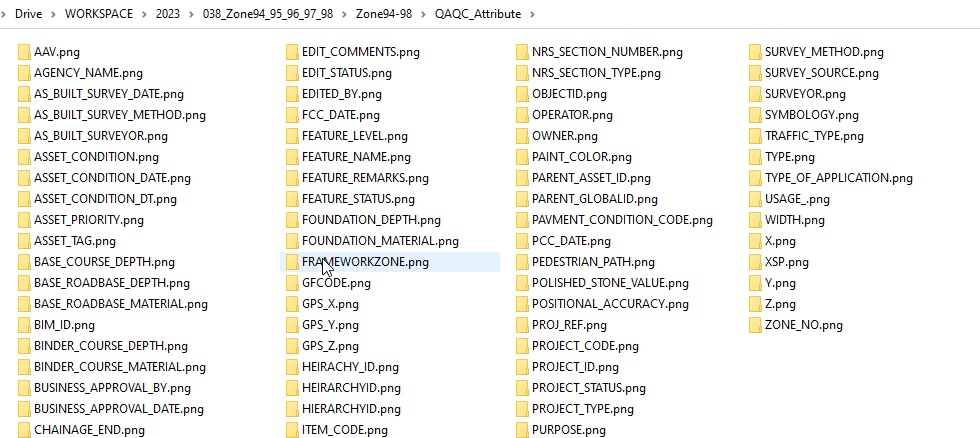

```python
# set the path to the folder containing images
image_folder = r"E:/Drive/WORKSPACE/2023/038_Zone94_95_96_97_98/Zone94-98/QAQC_Attribute/"

# iterate over images in the folder
for filename in os.listdir(image_folder):
    if filename.endswith(".jpg") or filename.endswith(".png"):

        # We extract caption text after the "-" character
        caption = filename.split("-")[1].strip()

        # We create a new folder for the caption text if it doesn't exist
        caption_folder = os.path.join(image_folder, caption)
        if not os.path.exists(caption_folder):
            os.mkdir(caption_folder)

        # move the image file to the caption folder
        source_path = os.path.join(image_folder, filename)
        destination_path = os.path.join(caption_folder, filename)
        shutil.move(source_path, destination_path)
```

[output not shown]

### 3.2 Removing Extension .png or .jpg from the folder name

```python
# set path to directory containing folders
folder_path = r"E:/Drive/WORKSPACE/2023/038_Zone94_95_96_97_98/Zone94-98/QAQC_Attribute/"

# iterate over folders in the directory
for folder_name in os.listdir(folder_path):
    # checking if folder name ends with ".png"
    if folder_name.endswith(".png"):
        # construct new folder name without ".png" extension
        new_folder_name = folder_name[:-4]
        # rename the folder with the new name
        os.rename(os.path.join(folder_path, folder_name), os.path.join(folder_path, new_folder_name))
```

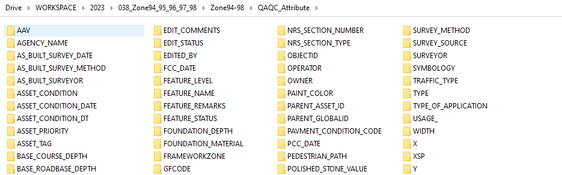

## 4. Create Word Document

- A word document is created based on the folder name. Most feature classes have similar attribute field.
- One word document for similar attribute field for all feature classes. One page with four plots.
- Easy to visualise at a go rather than querying in ArcMap.

### 4.1 Folder name to word documents by name

Finally, word document are populated based on the folder name and the images inside plotted in the word, as seen below

[figure not shown]

```python
# specify the root directory
root_directory = r"E:/Drive/WORKSPACE/2023/038_Zone94_95_96_97_98/Zone94-98/QAQC_Attribute/"

# create an empty list to store the folder paths
folder_list = []

# iterate over the directories in the root directory
for directory in os.listdir(root_directory):
    # check if the directory is a folder
    if os.path.isdir(os.path.join(root_directory, directory)):
        # add the directory path to the list
        folder_list.append(os.path.join(root_directory, directory))

# print the list of folder paths
for image_folder in folder_list:
    # set path to folder containing images
    #image_folder = r"D:/Drive/WORKSPACE/2023/014_QAQC_Data_Enhancement/Images/STREET LIGHT DATASET/GFCODE"
    document = image_folder.split('/')[-1]
    title = "Attribute Name: "+document
    document2 = document+'.docx'
    # create a new Word document
    doc = docx.Document()

    # add the attribute field title above the table
    p = doc.add_paragraph(title)
    p.style = 'Heading 2'
    p.alignment = WD_ALIGN_PARAGRAPH.CENTER

    # set up table for images
    table = doc.add_table(rows=3, cols=2)

    # set the style of the table borders
    table.style = 'Table Grid'

    # iterate over images in the folder and add them to the table
    for i, filename in enumerate(os.listdir(image_folder)):
        if filename.endswith(".jpg") or filename.endswith(".png"):
            if i >= 4:

                d = i//2
                row = i // d  # calculate row number based on iteration
                col = i % d   # calculate column number based on iteration

            elif i < 4:

                row = i // 2  # calculate row number based on iteration
                col = i % 2  # calculate column number based on iteration

            cell = table.cell(row, col)
            p = cell.add_paragraph()
            r = p.add_run()
            r.add_picture(os.path.join(image_folder, filename), width=Inches(3), height=Inches(3))
            p.alignment = WD_ALIGN_PARAGRAPH.CENTER


            # add the figure caption
            caption = filename.split("-")[0]
            p = cell.add_paragraph("Feature Class " +str(i+1)+": "+ caption)

            p.alignment = WD_ALIGN_PARAGRAPH.CENTER
            p.style = 'Body Text'

            doc.save(root_directory + document2)
```

### 4.2 Image Plot Explanation

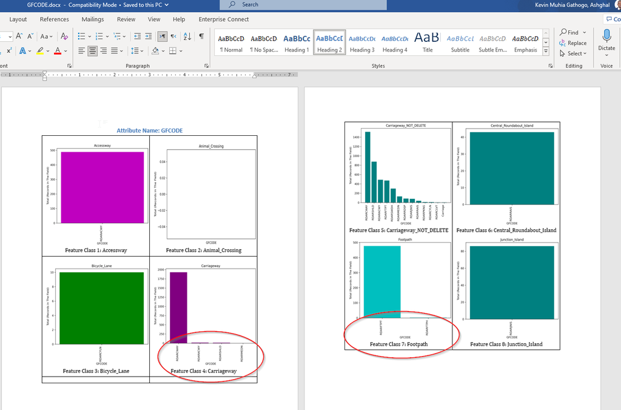

From the above images/plots,

- **The title** is the attribute name.
- **X-axis** is unique values in the field.
- **Y-axis** is the count of the unique elements.
- **Figure element at the bottom** is the Feature class count and name.

*SUMMARY - From the above*

## 5. Conclusion

- Check of Attributes is comprehensive, covering every single attribute field of the database.
- This plot and number of word documents gives insight of how many unique fields we have in a database.
- It can be used as a .py file and be embeded into arcMap or ArcGIS pro as a script tool.
- Word document gives a means of documenting the error as part of QAQC report, with supporting visible evidence of nature of a database.
- Possibility of Transfer learning to other tasks using the same technique in different case study.
- The code has room for improvement and enhacement to suite a specific .gdb need.
- Blindly one can estimate the amount of data in a database.